# Genome-wide methylation analysis report

# Genome-wide methylation analysis report

- study: Pleural cfDNAm analysis of meso_bape.platevariable
- author: Paul Yousefi
- date: 08 October, 2026

## Parameters

```
## $sig.threshold
## [1] 2.121143e-07
##
## $max.plots
## [1] 10
##
## $qq.inflation.method
## [1] "median"
##
## $practical.threshold
## [1] 5.786895e-05
```

## Sample characteristics

For continuous or ordinal variables, the “mean” column provides the mean and the “sd/%” column the standard deviation of the variable. For categorical variables, the “mean” column provides the number of samples with the given “value” and the “sd/%” column the percentage of samples with the given “value”.

| variable | value | mean | sd.. |
| --- | --- | --- | --- |
| meso_bape |  | 0.7407407 | 0.4409586 |
| plate |  | 2.37037 | 1.089087 |
| sv1 |  | -1.714813e-18 | 0.1118034 |
| sv2 |  | -3.489525e-18 | 0.1118034 |
| sv3 |  | -1.243746e-17 | 0.1118034 |
| sv4 |  | 2.026856e-18 | 0.1118034 |
| sv5 |  | -7.830851e-18 | 0.1118034 |
| sv6 |  | 2.022439e-17 | 0.1118034 |
| sv7 |  | 1.038552e-16 | 0.1118034 |
| sv8 |  | 2.644971e-16 | 0.1118034 |
| sv9 |  | 3.822292e-14 | 0.1118034 |
| sv10 |  | 2.293167e-12 | 0.1118034 |

## Covariate associations

### Covariate plate

statistics

| var1 | var2 | F | p-value | R | p-value |
| --- | --- | --- | --- | --- | --- |
| meso_bape | plate | 1.487086 | 0.2262976 | -0.1334775 | 0.2348529 |

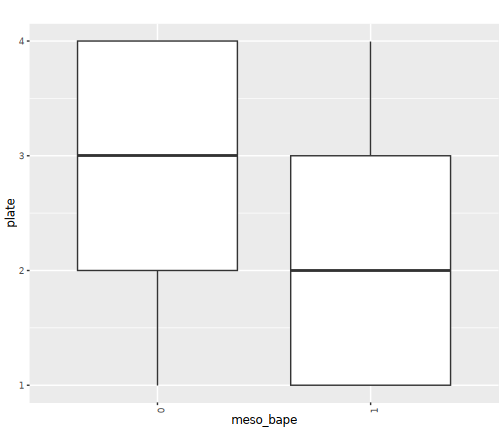

### Covariate sv1

statistics

| var1 | var2 | F | p-value | R | p-value |
| --- | --- | --- | --- | --- | --- |
| meso_bape | sv1 | 1.5078 | 0.2231211 | 0.1542281 | 0.1692186 |

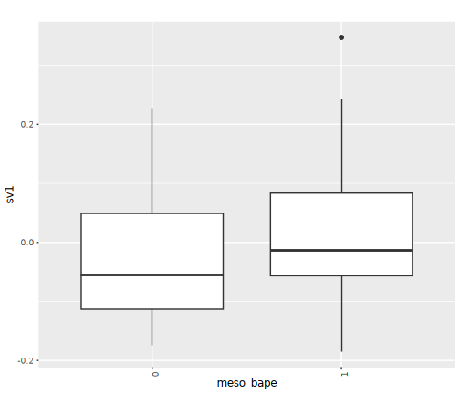

### Covariate sv2

statistics

| var1 | var2 | F | p-value | R | p-value |
| --- | --- | --- | --- | --- | --- |
| meso_bape | sv2 | 3e-07 | 0.9995523 | -0.0048196 | 0.9659385 |

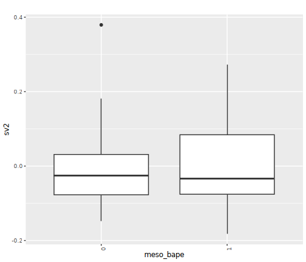

### Covariate sv3

statistics

| var1 | var2 | F | p-value | R | p-value |
| --- | --- | --- | --- | --- | --- |
| meso_bape | sv3 | 0.1603911 | 0.6898777 | -0.1253103 | 0.2649944 |

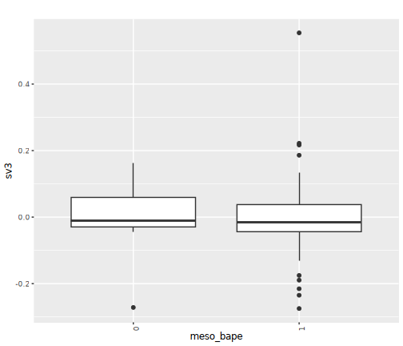

### Covariate sv4

statistics

| var1 | var2 | F | p-value | R | p-value |
| --- | --- | --- | --- | --- | --- |
| meso_bape | sv4 | 0.1084381 | 0.7428008 | -0.0301227 | 0.789507 |

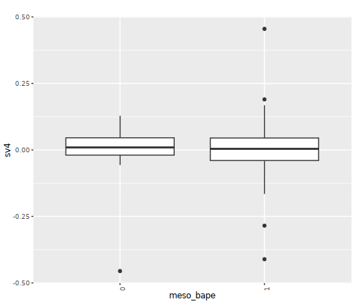

### Covariate sv5

statistics

| var1 | var2 | F | p-value | R | p-value |
| --- | --- | --- | --- | --- | --- |
| meso_bape | sv5 | 0.03546 | 0.8511179 | -0.0048196 | 0.9659385 |

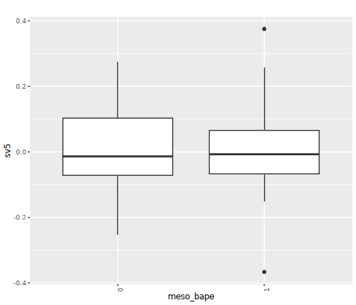

### Covariate sv6

statistics

| var1 | var2 | F | p-value | R | p-value |
| --- | --- | --- | --- | --- | --- |
| meso_bape | sv6 | 0.1131712 | 0.7374543 | 0.0301227 | 0.789507 |

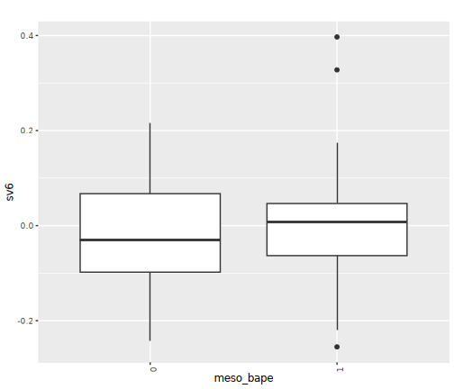

### Covariate sv7

statistics

| var1 | var2 | F | p-value | R | p-value |
| --- | --- | --- | --- | --- | --- |
| meso_bape | sv7 | 0.1439643 | 0.7053893 | 0.0156638 | 0.889615 |

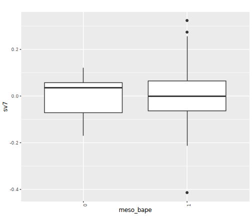

### Covariate sv8

statistics

| var1 | var2 | F | p-value | R | p-value |
| --- | --- | --- | --- | --- | --- |
| meso_bape | sv8 | 1.100928 | 0.2972618 | 0.0554257 | 0.6231038 |

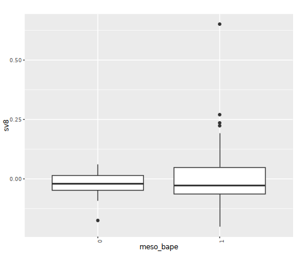

### Covariate sv9

statistics

| var1 | var2 | F | p-value | R | p-value |
| --- | --- | --- | --- | --- | --- |
| meso_bape | sv9 | 0.0034016 | 0.9536387 | 0.0156638 | 0.889615 |

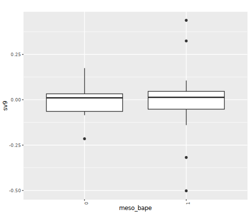

### Covariate sv10

statistics

| var1 | var2 | F | p-value | R | p-value |
| --- | --- | --- | --- | --- | --- |
| meso_bape | sv10 | 0.000369 | 0.9847235 | -0.0036147 | 0.9744506 |

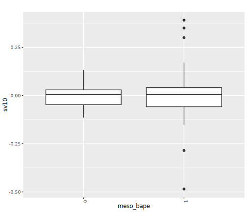

## QQ plots

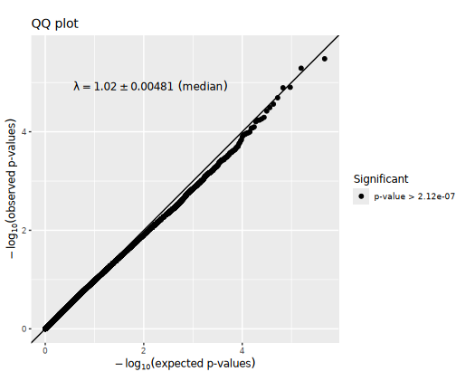

## Manhattan plots

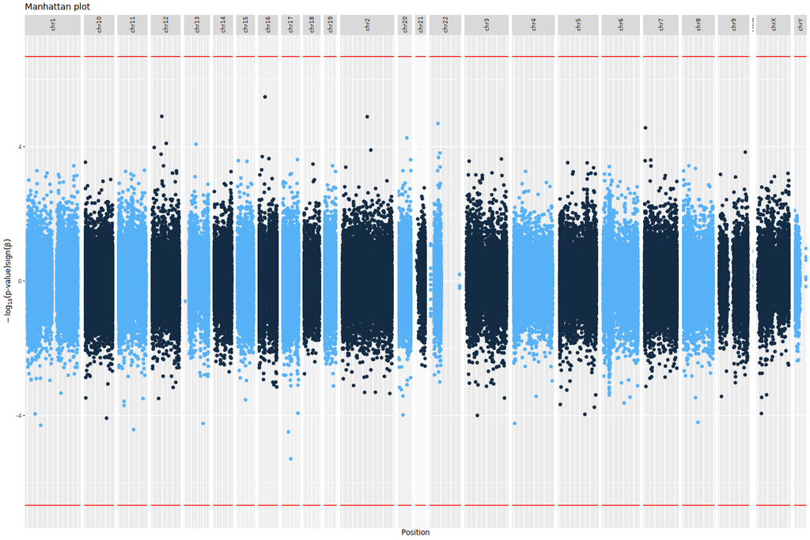

## Significant CpG sites

There were 0 CpG sites with association p-values < 2.1211427 × 10<sup>-7</sup>. These are listed in the file associations.csv.

[output not shown]

Plots of these sites follow, one for each covariate set. “p[lm]” denotes the p-value obtained using a linear model and “p[beta]” the p-value obtained using beta regression.

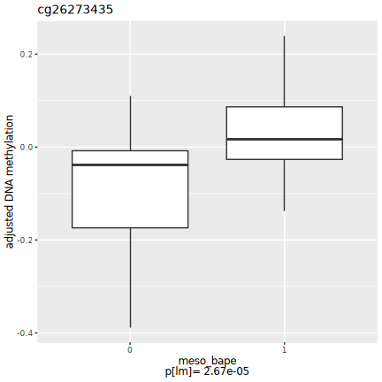

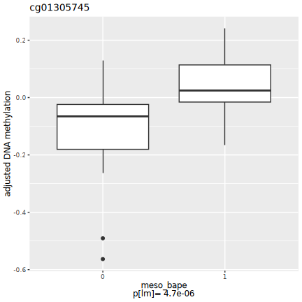

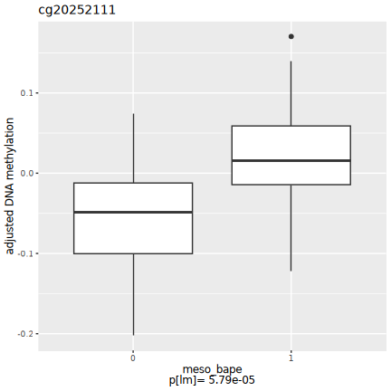

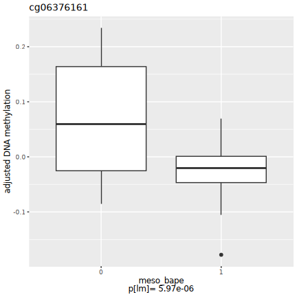

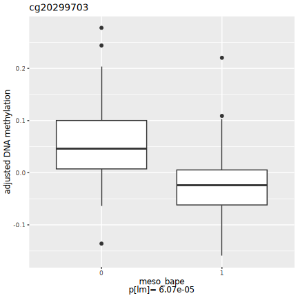

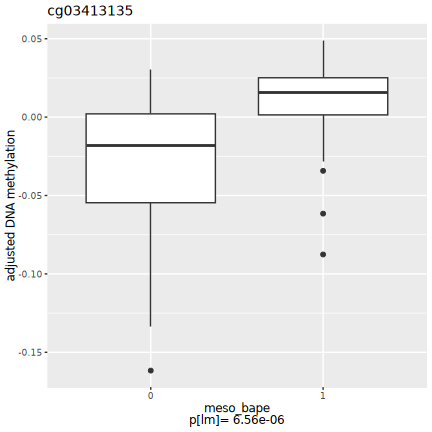

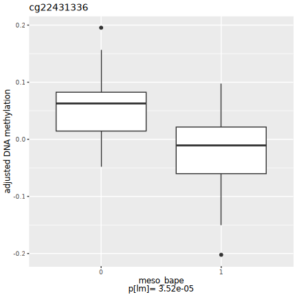

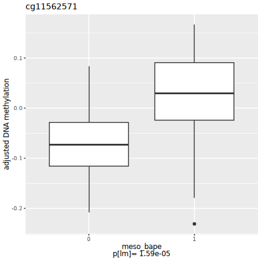

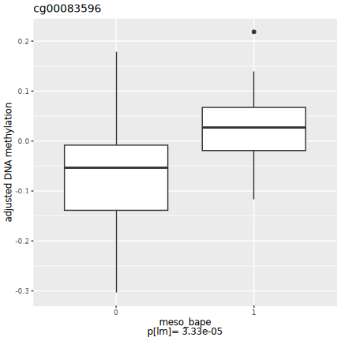

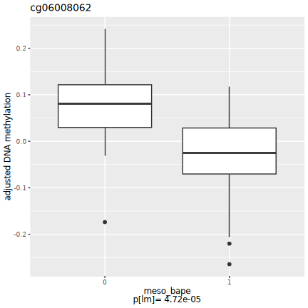

## Selected CpG sites

Number of CpG sites selected: 0.

| chromosome | position | estimate | p.value | p.adjust |
| --- | --- | --- | --- | --- |